# lab02

### Machine Learning : Dry Beans dataset

### Rishee Barthakur

This demonstrates working with files and analyzing the data.  
**The Dataset** : We are using Dry Beans dataset which holds the features of different beans including their categories such as DERMASON,SEKER, BOMBAY etc. So, here we will perform Machine Learning operation after analyzing the data and we will cover Support Vactor Machine(SVM) and Stochastic Gradient Descent(SGD). We will make a training set of 80% and test set of 20% for the operations and at the end we will compare the accuracy of both the models and will see which model would be more suitable for this data.

### Importing libraries

All the libraries are imported here

```python
import pandas as pd
import numpy as np
import os

from sklearn.linear_model import LinearRegression
from sklearn.model_selection import train_test_split
from sklearn.tree import DecisionTreeRegressor
import matplotlib.pyplot as plt
from sklearn.metrics import mean_squared_error

##reading file
from openpyxl import load_workbook

##for Feature selection
from sklearn.preprocessing import StandardScaler
from sklearn.preprocessing import MinMaxScaler
from sklearn.pipeline import make_pipeline

##for data cleaning
from sklearn.impute import SimpleImputer

##for classification
from sklearn.linear_model import SGDClassifier
from sklearn.svm import SVC

##for confusion matrix and accuracy related library
from sklearn.metrics import confusion_matrix,plot_confusion_matrix,accuracy_score,classification_report

#for interactive graph
import seaborn as sns
```

### Reading file

```python
try:
    y = os.path.join('DryBeanDataset','Dry_Bean_Dataset.xlsx')
    file = pd.read_excel(y)
except:
  print("File path error")
```

### Loading the dataset

We have loaded the dataset after reoving the null values (even though there is no null values) but in case if we get any null values.

```python
file = file.dropna()
file
```

|  | Area | Perimeter | MajorAxisLength | MinorAxisLength | AspectRation | Eccentricity | ConvexArea | EquivDiameter | Extent | Solidity | roundness | Compactness | ShapeFactor1 | ShapeFactor2 | ShapeFactor3 | ShapeFactor4 | Class |
| --- | --- | --- | --- | --- | --- | --- | --- | --- | --- | --- | --- | --- | --- | --- | --- | --- | --- |
| 0 | 28395 | 610.291 | 208.178117 | 173.888747 | 1.197191 | 0.549812 | 28715 | 190.141097 | 0.763923 | 0.988856 | 0.958027 | 0.913358 | 0.007332 | 0.003147 | 0.834222 | 0.998724 | SEKER |
| 1 | 28734 | 638.018 | 200.524796 | 182.734419 | 1.097356 | 0.411785 | 29172 | 191.272750 | 0.783968 | 0.984986 | 0.887034 | 0.953861 | 0.006979 | 0.003564 | 0.909851 | 0.998430 | SEKER |
| 2 | 29380 | 624.110 | 212.826130 | 175.931143 | 1.209713 | 0.562727 | 29690 | 193.410904 | 0.778113 | 0.989559 | 0.947849 | 0.908774 | 0.007244 | 0.003048 | 0.825871 | 0.999066 | SEKER |
| 3 | 30008 | 645.884 | 210.557999 | 182.516516 | 1.153638 | 0.498616 | 30724 | 195.467062 | 0.782681 | 0.976696 | 0.903936 | 0.928329 | 0.007017 | 0.003215 | 0.861794 | 0.994199 | SEKER |
| 4 | 30140 | 620.134 | 201.847882 | 190.279279 | 1.060798 | 0.333680 | 30417 | 195.896503 | 0.773098 | 0.990893 | 0.984877 | 0.970516 | 0.006697 | 0.003665 | 0.941900 | 0.999166 | SEKER |
| ... | ... | ... | ... | ... | ... | ... | ... | ... | ... | ... | ... | ... | ... | ... | ... | ... | ... |
| 13606 | 42097 | 759.696 | 288.721612 | 185.944705 | 1.552728 | 0.765002 | 42508 | 231.515799 | 0.714574 | 0.990331 | 0.916603 | 0.801865 | 0.006858 | 0.001749 | 0.642988 | 0.998385 | DERMASON |
| 13607 | 42101 | 757.499 | 281.576392 | 190.713136 | 1.476439 | 0.735702 | 42494 | 231.526798 | 0.799943 | 0.990752 | 0.922015 | 0.822252 | 0.006688 | 0.001886 | 0.676099 | 0.998219 | DERMASON |
| 13608 | 42139 | 759.321 | 281.539928 | 191.187979 | 1.472582 | 0.734065 | 42569 | 231.631261 | 0.729932 | 0.989899 | 0.918424 | 0.822730 | 0.006681 | 0.001888 | 0.676884 | 0.996767 | DERMASON |
| 13609 | 42147 | 763.779 | 283.382636 | 190.275731 | 1.489326 | 0.741055 | 42667 | 231.653248 | 0.705389 | 0.987813 | 0.907906 | 0.817457 | 0.006724 | 0.001852 | 0.668237 | 0.995222 | DERMASON |
| 13610 | 42159 | 772.237 | 295.142741 | 182.204716 | 1.619841 | 0.786693 | 42600 | 231.686223 | 0.788962 | 0.989648 | 0.888380 | 0.784997 | 0.007001 | 0.001640 | 0.616221 | 0.998180 | DERMASON |

13611 rows × 17 columns

### Features of the dataset

Showing the features of the dataset by using function info()

```python
file.info()
```

```
<class 'pandas.core.frame.DataFrame'>
Int64Index: 13611 entries, 0 to 13610
Data columns (total 17 columns):
 #   Column           Non-Null Count  Dtype
---  ------           --------------  -----
 0   Area             13611 non-null  int64
 1   Perimeter        13611 non-null  float64
 2   MajorAxisLength  13611 non-null  float64
 3   MinorAxisLength  13611 non-null  float64
 4   AspectRation     13611 non-null  float64
 5   Eccentricity     13611 non-null  float64
 6   ConvexArea       13611 non-null  int64
 7   EquivDiameter    13611 non-null  float64
 8   Extent           13611 non-null  float64
 9   Solidity         13611 non-null  float64
 10  roundness        13611 non-null  float64
 11  Compactness      13611 non-null  float64
 12  ShapeFactor1     13611 non-null  float64
 13  ShapeFactor2     13611 non-null  float64
 14  ShapeFactor3     13611 non-null  float64
 15  ShapeFactor4     13611 non-null  float64
 16  Class            13611 non-null  object
dtypes: float64(14), int64(2), object(1)
memory usage: 1.9+ MB
```

Total we have 17 features(colums) in this dataset.The info() function also shows the data types of the columns.

### Feature selection

```python
file.describe()
```

|  | Area | Perimeter | MajorAxisLength | MinorAxisLength | AspectRation | Eccentricity | ConvexArea | EquivDiameter | Extent | Solidity | roundness | Compactness | ShapeFactor1 | ShapeFactor2 | ShapeFactor3 | ShapeFactor4 |
| --- | --- | --- | --- | --- | --- | --- | --- | --- | --- | --- | --- | --- | --- | --- | --- | --- |
| count | 13611.000000 | 13611.000000 | 13611.000000 | 13611.000000 | 13611.000000 | 13611.000000 | 13611.000000 | 13611.000000 | 13611.000000 | 13611.000000 | 13611.000000 | 13611.000000 | 13611.000000 | 13611.000000 | 13611.000000 | 13611.000000 |
| mean | 53048.284549 | 855.283459 | 320.141867 | 202.270714 | 1.583242 | 0.750895 | 53768.200206 | 253.064220 | 0.749733 | 0.987143 | 0.873282 | 0.799864 | 0.006564 | 0.001716 | 0.643590 | 0.995063 |
| std | 29324.095717 | 214.289696 | 85.694186 | 44.970091 | 0.246678 | 0.092002 | 29774.915817 | 59.177120 | 0.049086 | 0.004660 | 0.059520 | 0.061713 | 0.001128 | 0.000596 | 0.098996 | 0.004366 |
| min | 20420.000000 | 524.736000 | 183.601165 | 122.512653 | 1.024868 | 0.218951 | 20684.000000 | 161.243764 | 0.555315 | 0.919246 | 0.489618 | 0.640577 | 0.002778 | 0.000564 | 0.410339 | 0.947687 |
| 25% | 36328.000000 | 703.523500 | 253.303633 | 175.848170 | 1.432307 | 0.715928 | 36714.500000 | 215.068003 | 0.718634 | 0.985670 | 0.832096 | 0.762469 | 0.005900 | 0.001154 | 0.581359 | 0.993703 |
| 50% | 44652.000000 | 794.941000 | 296.883367 | 192.431733 | 1.551124 | 0.764441 | 45178.000000 | 238.438026 | 0.759859 | 0.988283 | 0.883157 | 0.801277 | 0.006645 | 0.001694 | 0.642044 | 0.996386 |
| 75% | 61332.000000 | 977.213000 | 376.495012 | 217.031741 | 1.707109 | 0.810466 | 62294.000000 | 279.446467 | 0.786851 | 0.990013 | 0.916869 | 0.834270 | 0.007271 | 0.002170 | 0.696006 | 0.997883 |
| max | 254616.000000 | 1985.370000 | 738.860153 | 460.198497 | 2.430306 | 0.911423 | 263261.000000 | 569.374358 | 0.866195 | 0.994677 | 0.990685 | 0.987303 | 0.010451 | 0.003665 | 0.974767 | 0.999733 |

The dataset shows features of dry beans such area, perimeter, major axis length, nimor axis leanth etc. So in the next step we will visualize the data to understand the features better. We will be selecting Area, Perimeter, MajorAxisLength, MinorAxisLength, EquivDiameter and ConvexArea because it has good standard deviation and it will cover more data points.

```python
#For ploting graph we should also have the Class column in the dataset then only the libery will read the data and show out put
selective_features = file[['Area','Perimeter','MajorAxisLength','MinorAxisLength','EquivDiameter','ConvexArea','Class']]
```

### Dependent and Independent variables

Dependent and independent variables for running the model, so the Class will be the dependent variable and all the other columns will be the independent variables based on which Class values will be predicted

```python
#putting only class
dependent_variable = file[['Class']]

#putting all the other columns apart from class
independent_variables = file.iloc[:,:16]
```

### Scatter matrix

We will use the scatter_matrix function also sea born for better visualization

###### Scatter matrix using seaborn may take some time to run and may require external library installed

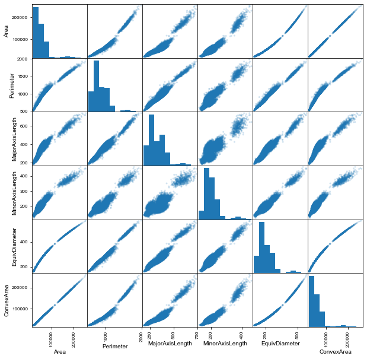

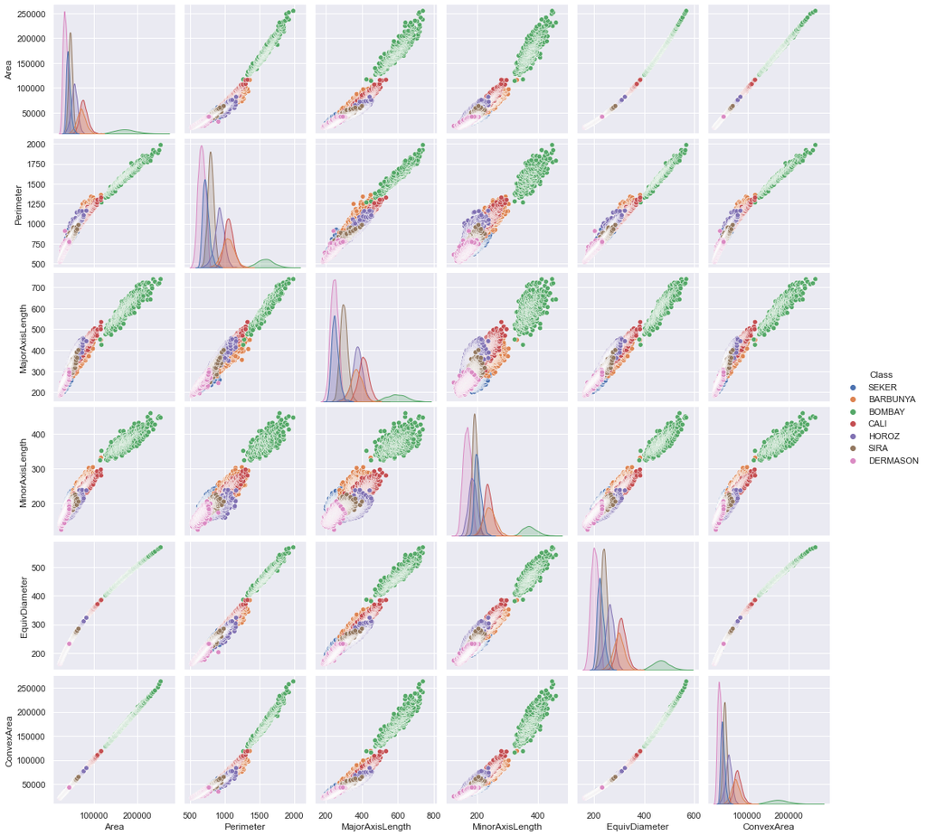

```python
##Scatter matrix using scatter_matrix()
pd.plotting.scatter_matrix(selective_features, alpha=0.2,figsize=(10,10));


##scatter matrix using seaborn for better visualization
sns.set()
##classify the data points on the basis of class values
print(sns.pairplot(selective_features, hue='Class'))
```

###### What we observe from the graphs

1. Minor axis and major axis length has good variance including the perimeters.
2. Relationship between Area and Convex area of the beans are linear and positive.
3. Relationship between Equiv diameter, convex length is almost linear.
4. Bombay beans are quite different from other beans.
5. Bombay beans are the largest in size then others.
6. Dermason beans are the smallest amongst all the beans.
7. Except bombay beans other beans are quite similar as the features like major axis length, minor axis length ,perimeter, area equiv diameter and convex areas are almost similar and don't differ much as bombay beans do

### Number of instances of class

Displaying the instances

```
Number of instances in class
DERMASON    3546
SIRA        2636
SEKER       2027
HOROZ       1928
CALI        1630
BARBUNYA    1322
BOMBAY       522
Name: Class, dtype: int64
```

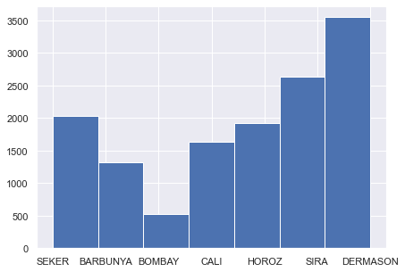

```python
print("Number of instances in class")
print(file['Class'].value_counts())

#plotting graph

plt.figure(figsize=(7,5))
plt.hist(file['Class'],bins=7)
plt.show()
```

We have highest number of Dermason followed by Sira and lowest is Bombay dry beans amongst all.

### Test and training set

we will be using 80% data in the test set and 20% data in the test set. We assign random state to have consistant value while running the program multiple times, test_size=0.2 represents 20% of the data will be used in the testset

```python
X_train, X_test = train_test_split(independent_variables,test_size=0.2, random_state=42)
Y_train ,Y_test =  train_test_split(dependent_variable,test_size=0.2, random_state=42)

print("Rows in main dataset : ",len(file))
print("Rows in train set : ",len(X_train))
print("Rows in test set : ",len(X_test))
```

```
Rows in main dataset :  13611
Rows in train set :  10888
Rows in test set :  2723
```

### Feature scaling

Why feature scaling? We are using feature scaling to get a proper euclidean distance which will help us to get a proper reasult for our model We will be using StandardScaler and use fit_transform() for feature selection fit_transform() will autometically transform the values after fitting it into our model.

we will exclude the class column because it does not consist of numerical values We are ignoring the categorical column and only considering the numeric column for feature scaling

```python
ss = StandardScaler()

#X_train and X_test holds the numerical values with wide range
trainX = ss.fit_transform(X_train)
testX = ss.fit_transform(X_test)

## describing the standard scalar model
print("---------Train set-------")
print(pd.DataFrame(trainX).describe())
print("\n---------Test set-------")
print(pd.DataFrame(testX).describe())
```

```
---------Train set-------
                 0             1             2             3             4   \
count  1.088800e+04  1.088800e+04  1.088800e+04  1.088800e+04  1.088800e+04
mean  -9.150061e-17  1.063644e-15  4.105827e-16  2.163478e-16  1.226466e-16
std    1.000046e+00  1.000046e+00  1.000046e+00  1.000046e+00  1.000046e+00
min   -1.118361e+00 -1.546068e+00 -1.595047e+00 -1.783416e+00 -2.265833e+00
25%   -5.724969e-01 -7.095905e-01 -7.815626e-01 -5.941351e-01 -6.086553e-01
50%   -2.861585e-01 -2.835314e-01 -2.743762e-01 -2.162333e-01 -1.294455e-01
75%    2.886981e-01  5.757689e-01  6.606019e-01  3.297265e-01  5.053249e-01
max    6.952807e+00  5.311620e+00  4.915197e+00  5.791775e+00  3.275149e+00

                 5             6             7             8             9   \
count  1.088800e+04  1.088800e+04  1.088800e+04  1.088800e+04  1.088800e+04
mean   2.272857e-16  2.247365e-17 -1.393795e-16 -1.226262e-15  8.852642e-15
std    1.000046e+00  1.000046e+00  1.000046e+00  1.000046e+00  1.000046e+00
min   -5.788975e+00 -1.116860e+00 -1.556341e+00 -3.964029e+00 -1.459377e+01
25%   -3.765456e-01 -5.747196e-01 -6.439888e-01 -6.399232e-01 -3.172282e-01
50%    1.476127e-01 -2.878869e-01 -2.467074e-01  1.963983e-01  2.444364e-01
75%    6.497484e-01  2.917017e-01  4.516323e-01  7.622478e-01  6.140056e-01
max    1.713475e+00  7.117101e+00  5.388074e+00  2.382327e+00  1.617990e+00

                 10            11            12            13            14  \
count  1.088800e+04  1.088800e+04  1.088800e+04  1.088800e+04  1.088800e+04
mean   6.425793e-16  9.118553e-16 -4.922179e-16 -1.878651e-16  7.676323e-16
std    1.000046e+00  1.000046e+00  1.000046e+00  1.000046e+00  1.000046e+00
min   -6.448769e+00 -2.509532e+00 -3.365782e+00 -1.935196e+00 -2.299246e+00
25%   -6.824770e-01 -6.083069e-01 -5.907731e-01 -9.454253e-01 -6.308512e-01
50%    1.670835e-01  2.263621e-02  7.002234e-02 -2.470077e-02 -1.581319e-02
75%    7.331301e-01  5.529752e-01  6.308798e-01  7.640667e-01  5.248110e-01
max    1.924562e+00  3.039581e+00  3.445869e+00  3.271024e+00  3.347774e+00

                 15
count  1.088800e+04
mean   2.729305e-15
std    1.000046e+00
min   -1.091596e+01
25%   -3.099199e-01
50%    3.050007e-01
75%    6.439112e-01
max    1.068241e+00
```

[output cut: 26 more lines]

```
min   -4.491739e+00 -2.557088e+00 -3.250301e+00 -1.905801e+00 -2.335313e+00
25%   -7.063668e-01 -5.947985e-01 -5.971592e-01 -9.341750e-01 -6.181137e-01
50%    1.604332e-01  2.009723e-02  8.322060e-02 -6.772155e-02 -1.866243e-02
75%    7.347017e-01  5.707284e-01  6.184504e-01  7.554720e-01  5.429865e-01
max    1.978825e+00  2.858587e+00  2.753691e+00  3.118324e+00  3.128060e+00

                 15
count  2.723000e+03
mean  -3.350545e-15
std    1.000184e+00
min   -8.461054e+00
25%   -3.243847e-01
50%    3.034392e-01
75%    6.542097e-01
max    1.041751e+00
```

### 1. Support vactor machine

we are making the SVM using SVC() function from the library and we are using kernal as rbf (hyperparameter)

### rbf gamma=0.1 and C=10

decision_function_shape='ovo' for one vs one

```
---------------------------------------
           rbf, gamma=0.1 and C=10
-----------------------------------------
Accuracy of our prediction 92.986 %
Accuracy of training set 92.986 %

              precision    recall  f1-score   support

    BARBUNYA       0.93      0.92      0.92       261
      BOMBAY       1.00      1.00      1.00       117
        CALI       0.94      0.93      0.94       317
    DERMASON       0.90      0.93      0.92       671
       HOROZ       0.97      0.95      0.96       408
       SEKER       0.97      0.95      0.96       413
        SIRA       0.88      0.88      0.88       536

    accuracy                           0.93      2723
   macro avg       0.94      0.94      0.94      2723
weighted avg       0.93      0.93      0.93      2723
```

```
<sklearn.metrics._plot.confusion_matrix.ConfusionMatrixDisplay at 0x1d798a018b0>
```

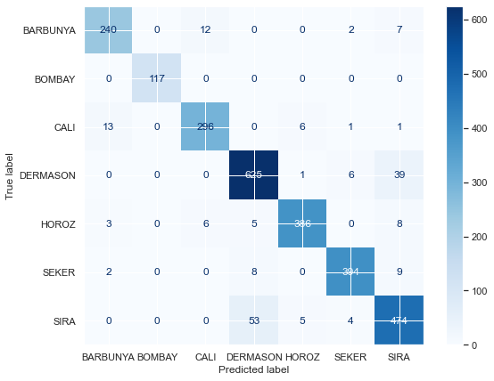

```python
#using only rbh as a hyperparameter
svc = SVC(kernel='rbf',gamma=0.1,C=10,decision_function_shape='ovo')

#Training model
svc.fit(trainX, Y_train)

#Testing model
y_pred=svc.predict(testX)
y_pred_train=svc.predict(trainX)

#accuracy rate
test_accuracy_svc = round(accuracy_score(Y_test,y_pred)*100,3)
train_accuracy_svc =round(accuracy_score(Y_train,y_pred_train)*100,3)


#confusion matrix
#print(confusion_matrix(Y_test,y_pred))
print("\n---------------------------------------")
print("           rbf, gamma=0.1 and C=10        ")
print("-----------------------------------------")
print("Accuracy of our prediction",test_accuracy_svc,"%")
print("Accuracy of training set",test_accuracy_svc,"%\n")

##classificatio report
print(classification_report(Y_test,y_pred))


#ploting confusion matrix
fig,ax=plt.subplots(figsize=(9,7))
plot_confusion_matrix(svc,testX,Y_test,cmap="Blues",ax=ax )
```

### rbf gamma=0.001 and C=99

```
---------------------------------------
          rbf gamma=0.001 and C=99
-----------------------------------------
Accuracy of our prediction 93.316 %
Accuracy of training set 92.79 %

              precision    recall  f1-score   support

    BARBUNYA       0.93      0.93      0.93       261
      BOMBAY       1.00      1.00      1.00       117
        CALI       0.95      0.94      0.95       317
    DERMASON       0.90      0.93      0.92       671
       HOROZ       0.98      0.97      0.97       408
       SEKER       0.97      0.95      0.96       413
        SIRA       0.89      0.88      0.88       536

    accuracy                           0.93      2723
   macro avg       0.95      0.94      0.94      2723
weighted avg       0.93      0.93      0.93      2723
```

```
<sklearn.metrics._plot.confusion_matrix.ConfusionMatrixDisplay at 0x1d798f96910>
```

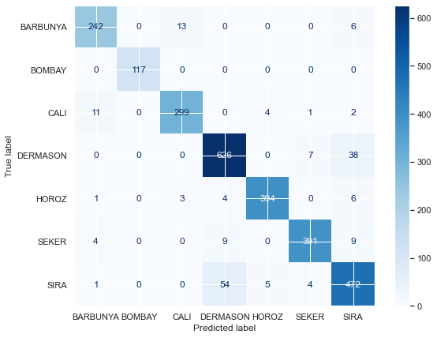

```python
##-----------------------------------------------------------------------------------------------------------##
##-----------------------------------------------------------------------------------------------------------##
##using different parameters
svc2 = SVC(kernel='rbf',gamma=0.001,C=99,decision_function_shape='ovo')

#Training model
svc2.fit(trainX, Y_train)

#Testing model
y_pred2=svc2.predict(testX)
y_pred_train2=svc2.predict(trainX)

#accuracy rate
test_accuracy_svc2 = round(accuracy_score(Y_test,y_pred2)*100,3)
train_accuracy_svc2 =round(accuracy_score(Y_train,y_pred_train2)*100,3)

#confusion matrix
#print(confusion_matrix(Y_test,y_pred2))
print("\n---------------------------------------")
print("          rbf gamma=0.001 and C=99       ")
print("-----------------------------------------")
print("Accuracy of our prediction",test_accuracy_svc2 ,"%")
print("Accuracy of training set",train_accuracy_svc2,"%\n")

#classification report
print(classification_report(Y_test,y_pred2))

#ploting confusion matrix
fig,ax=plt.subplots(figsize=(9,7))
plot_confusion_matrix(svc2,testX,Y_test,cmap="Blues",ax=ax )
```

```
---------------------------------------
-----------------------------------------
Accuracy of our prediction 93.133 %
Accuracy of training set 93.378 %

              precision    recall  f1-score   support

    BARBUNYA       0.94      0.92      0.93       261
      BOMBAY       1.00      1.00      1.00       117
        CALI       0.95      0.94      0.94       317
    DERMASON       0.90      0.93      0.92       671
       HOROZ       0.97      0.95      0.96       408
       SEKER       0.97      0.95      0.96       413
        SIRA       0.88      0.88      0.88       536

    accuracy                           0.93      2723
   macro avg       0.94      0.94      0.94      2723
weighted avg       0.93      0.93      0.93      2723
```

```
<sklearn.metrics._plot.confusion_matrix.ConfusionMatrixDisplay at 0x1d79ef5ca30>
```

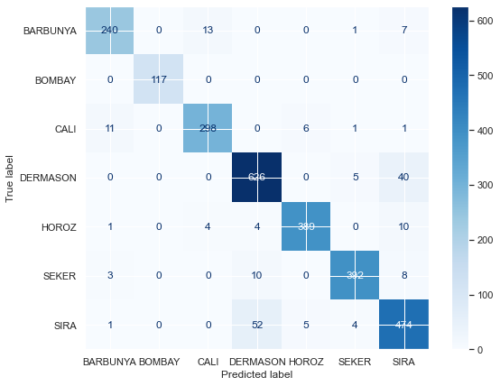

```python
##-----------------------------------------------------------------------------------------------------------##
##-----------------------------------------------------------------------------------------------------------##
##using different parameters
svc3 = SVC(kernel='rbf',gamma=0.1)

#Training model
svc3.fit(trainX, Y_train)

#Testing model
y_pred3=svc3.predict(testX)
y_pred_train3=svc3.predict(trainX)

#accuracy rate
test_accuracy_svc3 = round(accuracy_score(Y_test,y_pred3)*100,3)
train_accuracy_svc3 =round(accuracy_score(Y_train,y_pred_train3)*100,3)

#confusion matrix
#print(confusion_matrix(Y_test,y_pred2))
print("\n---------------------------------------")
#print("          rbf gamma=0.001 and C=99       ")
print("-----------------------------------------")
print("Accuracy of our prediction",test_accuracy_svc3 ,"%")
print("Accuracy of training set",train_accuracy_svc3,"%\n")

#classification report
print(classification_report(Y_test,y_pred3))

#ploting confusion matrix
fig,ax=plt.subplots(figsize=(9,7))
plot_confusion_matrix(svc3,testX,Y_test,cmap="Blues",ax=ax )
```

```
---------------------------------------
-----------------------------------------
Accuracy of our prediction 90.599 %
Accuracy of training set 97.272 %

              precision    recall  f1-score   support

    BARBUNYA       0.87      0.92      0.89       261
      BOMBAY       1.00      1.00      1.00       117
        CALI       0.92      0.91      0.92       317
    DERMASON       0.86      0.94      0.90       671
       HOROZ       0.96      0.91      0.93       408
       SEKER       0.96      0.88      0.92       413
        SIRA       0.88      0.85      0.87       536

    accuracy                           0.91      2723
   macro avg       0.92      0.92      0.92      2723
weighted avg       0.91      0.91      0.91      2723
```

```
<sklearn.metrics._plot.confusion_matrix.ConfusionMatrixDisplay at 0x1d79e8d45e0>
```

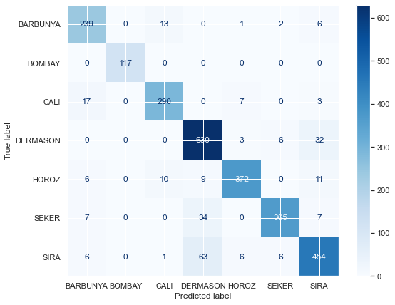

```python
##-----------------------------------------------------------------------------------------------------------##
##-----------------------------------------------------------------------------------------------------------##
##using different parameters
svc4 = SVC(kernel='poly',gamma=1,degree=5)

#Training model
svc4.fit(trainX, Y_train)

#Testing model
y_pred4=svc4.predict(testX)
y_pred_train4=svc4.predict(trainX)

#accuracy rate
test_accuracy_svc4 = round(accuracy_score(Y_test,y_pred4)*100,3)
train_accuracy_svc4 =round(accuracy_score(Y_train,y_pred_train4)*100,3)

#confusion matrix
#print(confusion_matrix(Y_test,y_pred2))
print("\n---------------------------------------")
#print("          rbf gamma=0.001 and C=99       ")
print("-----------------------------------------")
print("Accuracy of our prediction",test_accuracy_svc4 ,"%")
print("Accuracy of training set",train_accuracy_svc4,"%\n")

#classification report
print(classification_report(Y_test,y_pred4))

#ploting confusion matrix
fig,ax=plt.subplots(figsize=(9,7))
plot_confusion_matrix(svc4,testX,Y_test,cmap="Blues",ax=ax )
```

### Explanation

```python
print("Model 1 - Accuracy using gamma=0.1,C=10  :",test_accuracy_svc,"%")
print("Model 2 - Accuracy using gamma=0.001, C=99 is :",test_accuracy_svc2,"%")
```

```
Model 1 - Accuracy using gamma=0.1,C=10  : 92.986 %
Model 2 - Accuracy using gamma=0.001, C=99 is : 93.316 %
```

1. Lower value of gamma is considering the point which are far away and avoiding outliers
2. Higher value of C is creating smaller margin which is avoding misclassification for our model, reduces outliers

## 2. Stochastic Gradient Descent

```
              precision    recall  f1-score   support

    BARBUNYA       0.00      0.00      0.00       261
      BOMBAY       0.00      0.00      0.00       117
        CALI       0.00      0.00      0.00       317
    DERMASON       0.54      0.97      0.70       671
       HOROZ       0.42      0.44      0.43       408
       SEKER       0.75      0.97      0.85       413
        SIRA       0.31      0.33      0.32       536

    accuracy                           0.52      2723
   macro avg       0.29      0.39      0.33      2723
weighted avg       0.37      0.52      0.43      2723


---------------------------------------
-----------------------------------------
Accuracy of our prediction 51.708 %
Accuracy of training set 53.058 %
---------------------------------------
```

```
<sklearn.metrics._plot.confusion_matrix.ConfusionMatrixDisplay at 0x1d79f70ad60>
```

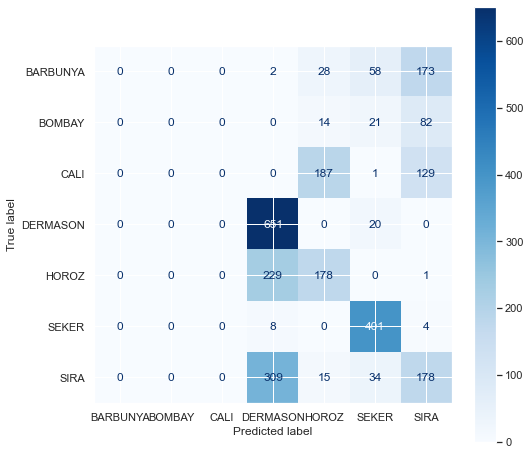

```python
#sgd = SGDClassifier(max_iter=1000)
sgd = SGDClassifier(penalty='elasticnet',alpha=1)
sgd.fit(trainX, Y_train)

#Testing model
y_pred_sgd=sgd.predict(testX)
y_pred_train_sgd=sgd.predict(trainX)


#accuracy rate
test_accuracy_sgd = round(accuracy_score(Y_test,y_pred_sgd)*100,3)
train_accuracy_sgd =round(accuracy_score(Y_train,y_pred_train_sgd)*100,3)

#classification report
print(classification_report(Y_test,y_pred_sgd))

#confusion matrix
#print(confusion_matrix(Y_test,y_pred_sgd))
print("\n---------------------------------------")
#print("             max_iter=1000  ")
print("-----------------------------------------")
print("Accuracy of our prediction",test_accuracy_sgd,"%")
print("Accuracy of training set",train_accuracy_sgd,"%")
print("---------------------------------------")

#ploting confusion matrix
fig,ax=plt.subplots(figsize=(8,8))
plot_confusion_matrix(sgd,testX,Y_test,cmap="Blues",ax=ax )
```

### max_iter=10

```
              precision    recall  f1-score   support

    BARBUNYA       0.92      0.91      0.91       261
      BOMBAY       1.00      0.98      0.99       117
        CALI       0.96      0.90      0.93       317
    DERMASON       0.82      0.96      0.88       671
       HOROZ       0.96      0.97      0.96       408
       SEKER       0.98      0.85      0.91       413
        SIRA       0.88      0.82      0.85       536

    accuracy                           0.91      2723
   macro avg       0.93      0.91      0.92      2723
weighted avg       0.91      0.91      0.91      2723


---------------------------------------
               max_iter=10
       ---------------------------
Accuracy of our prediction 90.562 %
Accuracy of training set 91.22 %
---------------------------------------
```

```
<sklearn.metrics._plot.confusion_matrix.ConfusionMatrixDisplay at 0x1d79e8cfac0>
```

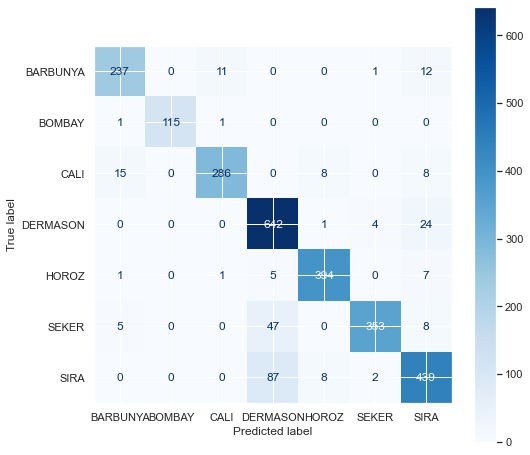

```python
sgd2 = SGDClassifier(max_iter=10)
sgd2.fit(trainX, Y_train)

#Testing model
y_pred_sgd2=sgd2.predict(testX)
y_pred_train_sgd2=sgd2.predict(trainX)


#accuracy rate
test_accuracy_sgd2 = round(accuracy_score(Y_test,y_pred_sgd2)*100,3)
train_accuracy_sgd2 =round(accuracy_score(Y_train,y_pred_train_sgd2)*100,3)

#classification report
print(classification_report(Y_test,y_pred_sgd2))

#confusion matrix
#print(confusion_matrix(Y_test,y_pred_sgd2))
print("\n---------------------------------------")
print("               max_iter=10       ")
print("       ---------------------------       ")
print("Accuracy of our prediction",test_accuracy_sgd2,"%")
print("Accuracy of training set",train_accuracy_sgd2,"%")
print("---------------------------------------")

#ploting confusion matrix
fig,ax=plt.subplots(figsize=(8,8))
plot_confusion_matrix(sgd2,testX,Y_test,cmap="Blues",ax=ax )
```

### Explanation

```python
print("Model 1 - SGD max_iter=1000  :",test_accuracy_sgd,"%")
print("Model 2 - SGD max_iter=10 :",test_accuracy_sgd2,"%")
value=0
if(test_accuracy_sgd2 < test_accuracy_sgd):
    value = test_accuracy_sgd
else:
    value = test_accuracy_sgd2
print("\nBest model is having accuracy",value,"%")
```

```
Model 1 - SGD max_iter=1000  : 51.708 %
Model 2 - SGD max_iter=10 : 90.562 %

Best model is having accuracy 90.562 %
```

## Comapring results

### SVM vs SGD

```python
print("Model accuracy rates")
print("SVM :",test_accuracy_svc2,"%")
print("SGD :",value,"%")
```

```
Model accuracy rates
SVM : 93.316 %
SGD : 90.562 %
```

##### **Conclusion**

**For our dataset the SVM (Support Vactor Machine) classifier seems to be better but however the difference is not that huge but we will still consider taking the SVM for our dataset for future predition as it is slightly better than the SGD**